# Etude Concernant les différents avions de Delta Air Lines

yahyaoui marwa

30 avril 2016

# 1.Résumé

Ce travail est une étude sur les différents avions de “Delta Air Lines” Nous avons travaillé sur une base de données contenant des variables indépendantes .Nous avons obtenu à l’aide d’une étude statistique qui mesure les différents caractéristique des Avions et on a remarqué qu’ils sont corrélées. Dont on a utilisé un ensemble de données intéressantes sur lesquelles on peut faire une analyse , car il possède à la fois des informations quantitatives et qualitatives et est relativement complexe.

# 2 introduction

Delta Air Lines :c’est une compagnie aérienne américaine Fondée en 1924 sous le nom de Huff Daland Dusters, est devenue la principale compagnie au monde avec avec 75 000 employés, desservant 375 destinations dans 66 pays,transportant chaque année plus de 160 millions de voyageurs vers leur destination. Son chiffre d’affaires est de 35,11 milliards de dollars USD (2011). Alors Que pouvons-nous dire sur les différents avions de Delta ?sur Quels plans sont similaires ? et sur Quels sont dissemblables ?

# 3.Données

Nous avons obtenu notre base de le site Web de Delta

au niveau des variables qualitatives 0 désigne non alors que 1 désigne oui

44 observations :représentant 44 modèles d’Avion dont la lettre A désigne l’Airbus, la lettre B désigne Boeing, la lettre E désigne Embraer et MC désigne McDonnell

# 4 Méthodologie

Comment pouvons- nous visualisons plus facile un jeu comme celui-ci des données de grande dimension ? En utilisant une technique de réduction de dimensionnalité , comme l’analyse en composantes principales .

Tout d’abord, on a extrait du jeu de données initial les variables actives qui permettent de décrire les caractéristiques des Avion.

Le travail va être comme suit :

2- centrer et réduire X.

3- V=(1/44)X’X matrice de var qui est définie positive.

4- diagonaliser V.

5- projection sur le premier plan principal.

On a utilisé Rstudio et la version 3.2.2 du logiciel R pour faire cette analyse en composantes principales et plus précisément la commande “FactoMineR”. Ceci est le code exécuté pour réaliser notre ACP :

```r
data <- read.table(file.choose(), header=T, sep=",", row.names=1)
View(data)
summary(data)
```

```
##  Seat.Width..Club. Seat.Pitch..Club.  Seat..Club.
##  Min.   : 0.0000   Min.   : 0        Min.   : 0.0000
##  1st Qu.: 0.0000   1st Qu.: 0        1st Qu.: 0.0000
##  Median : 0.0000   Median : 0        Median : 0.0000
##  Mean   : 0.4409   Mean   : 1        Mean   : 0.2727
##  3rd Qu.: 0.0000   3rd Qu.: 0        3rd Qu.: 0.0000
##  Max.   :19.4000   Max.   :44        Max.   :12.0000
##  Seat.Width..First.Class. Seat.Pitch..First.Class. Seats..First.Class.
##  Min.   : 0.00            Min.   : 0.00            Min.   : 0.00
##  1st Qu.: 0.00            1st Qu.: 0.00            1st Qu.: 0.00
##  Median :18.95            Median :36.00            Median :12.00
##  Mean   :11.49            Mean   :21.85            Mean   :10.55
##  3rd Qu.:21.00            3rd Qu.:37.00            3rd Qu.:17.00
##  Max.   :21.00            Max.   :60.00            Max.   :36.00
##  Seat.Width..Business. Seat.Pitch..Business. Seats..Business.
##  Min.   : 0.000        Min.   : 0.00         Min.   : 0.00
##  1st Qu.: 0.000        1st Qu.: 0.00         1st Qu.: 0.00
##  Median : 0.000        Median : 0.00         Median : 0.00
##  Mean   : 7.545        Mean   :25.55         Mean   :11.86
##  3rd Qu.:21.000        3rd Qu.:60.00         3rd Qu.:27.00
##  Max.   :21.000        Max.   :82.00         Max.   :48.00
##  Seat.Width..Eco.Comfort. Seat.Pitch..Eco.Comfort. Seats..Eco.Comfort.
##  Min.   : 0.00            Min.   : 0.00            Min.   : 0.00
##  1st Qu.:17.20            1st Qu.:34.00            1st Qu.:15.00
##  Median :17.30            Median :34.00            Median :19.50
##  Mean   :15.65            Mean   :30.58            Mean   :20.91
##  3rd Qu.:18.00            3rd Qu.:35.00            3rd Qu.:29.25
##  Max.   :18.50            Max.   :36.00            Max.   :42.00
##  Seat.Width..Economy. Seat.Pitch..Economy. Seats..Economy. Accommodation
##  Min.   : 0.00        Min.   : 0.00        Min.   :  0.0   Min.   : 28.0
##  1st Qu.:17.20        1st Qu.:30.50        1st Qu.: 93.0   1st Qu.:123.0
##  Median :17.60        Median :31.00        Median :132.0   Median :177.5
##  Mean   :17.25        Mean   :30.41        Mean   :129.7   Mean   :172.5
##  3rd Qu.:18.00        3rd Qu.:31.50        3rd Qu.:171.0   3rd Qu.:226.0
##  Max.   :18.50        Max.   :32.00        Max.   :286.0   Max.   :376.0
##  Cruising.Speed..mph. Range..miles.      Engines      Wingspan..ft.
##  Min.   :364.0        Min.   :  731   Min.   :2.000   Min.   : 64.92
##  1st Qu.:517.0        1st Qu.: 1944   1st Qu.:2.000   1st Qu.:107.83
##  Median :517.0        Median : 3174   Median :2.000   Median :129.79
##  Mean   :515.8        Mean   : 3869   Mean   :2.045   Mean   :132.10
```

[output cut: 15 more lines]

```
##  Max.   :1.0000   Max.   :1.0000   Max.   :1.0000   Max.   :1.0000
##       Club          First.Class        Business       Eco.Comfort
##  Min.   :0.00000   Min.   :0.0000   Min.   :0.0000   Min.   :0.0000
##  1st Qu.:0.00000   1st Qu.:0.0000   1st Qu.:0.0000   1st Qu.:1.0000
##  Median :0.00000   Median :1.0000   Median :0.0000   Median :1.0000
##  Mean   :0.02273   Mean   :0.5455   Mean   :0.3864   Mean   :0.8864
##  3rd Qu.:0.00000   3rd Qu.:1.0000   3rd Qu.:1.0000   3rd Qu.:1.0000
##  Max.   :1.00000   Max.   :1.0000   Max.   :1.0000   Max.   :1.0000
##     Economy
##  Min.   :0.0000
##  1st Qu.:1.0000
##  Median :1.0000
##  Mean   :0.9773
##  3rd Qu.:1.0000
##  Max.   :1.0000
```

```
## 'data.frame':    44 obs. of  33 variables:
##  $ Seat.Width..Club.       : num  0 19.4 0 0 0 0 0 0 0 0 ...
##  $ Seat.Pitch..Club.       : int  0 44 0 0 0 0 0 0 0 0 ...
##  $ Seat..Club.             : int  0 12 0 0 0 0 0 0 0 0 ...
##  $ Seat.Width..First.Class.: num  21 19.4 21 21 0 0 0 0 19.6 21 ...
##  $ Seat.Pitch..First.Class.: num  36 40 36 36 0 0 0 0 37 37 ...
##  $ Seats..First.Class.     : int  12 28 12 12 0 0 0 0 12 12 ...
##  $ Seat.Width..Business.   : num  0 21 0 0 21 21 21 20 0 0 ...
##  $ Seat.Pitch..Business.   : num  0 59 0 0 60 80 80 60 0 0 ...
##  $ Seats..Business.        : int  0 14 0 0 32 34 34 34 0 0 ...
##  $ Seat.Width..Eco.Comfort.: num  17.2 0 17.2 17.2 18 18 18 18 18.1 17.2 ...
##  $ Seat.Pitch..Eco.Comfort.: num  34 0 34 34 35 35 35 35 34 34 ...
##  $ Seats..Eco.Comfort.     : int  18 0 18 18 30 32 32 32 15 18 ...
##  $ Seat.Width..Economy.    : num  17.2 0 17.2 17.2 18 18 18 18 18.1 17.2 ...
##  $ Seat.Pitch..Economy.    : num  30.5 0 31.5 31.5 30.5 30.5 30.5 30.5 31 30.5 ...
```

[output cut: 19 more lines]

# 5-Analyse multivariée :

## 5.1 Analyse en Composantes Principales (ACP) :

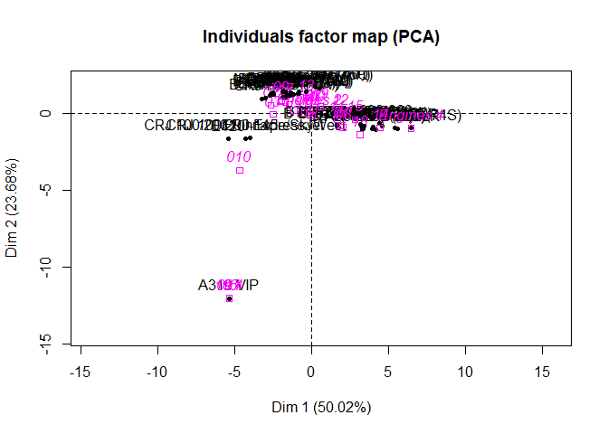

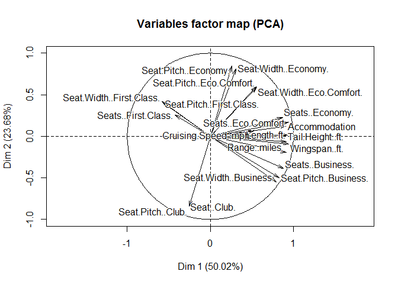

```r
library(FactoMineR)
res.pca=PCA(data,quali.sup=c(1,19,23:33))
```

```r
res.pca$eig
```

```
##           eigenvalue percentage of variance
## comp 1  1.000472e+01           5.002360e+01
## comp 2  4.735406e+00           2.367703e+01
## comp 3  3.410781e+00           1.705391e+01
## comp 4  8.276081e-01           4.138040e+00
## comp 5  4.655307e-01           2.327653e+00
## comp 6  2.351595e-01           1.175798e+00
## comp 7  9.588577e-02           4.794288e-01
## comp 8  7.414790e-02           3.707395e-01
## comp 9  4.604644e-02           2.302322e-01
## comp 10 2.868457e-02           1.434229e-01
## comp 11 2.089870e-02           1.044935e-01
## comp 12 1.754567e-02           8.772834e-02
## comp 13 1.407878e-02           7.039391e-02
## comp 14 1.052591e-02           5.262957e-02
## comp 15 5.847979e-03           2.923989e-02
## comp 16 3.731697e-03           1.865848e-02
## comp 17 2.504024e-03           1.252012e-02
## comp 18 6.599174e-04           3.299587e-03
## comp 19 2.360786e-04           1.180393e-03
## comp 20 2.121573e-30           1.060787e-29
##         cumulative percentage of variance
## comp 1                           50.02360
## comp 2                           73.70064
## comp 3                           90.75454
## comp 4                           94.89258
## comp 5                           97.22024
## comp 6                           98.39603
## comp 7                           98.87546
## comp 8                           99.24620
## comp 9                           99.47643
## comp 10                          99.61986
## comp 11                          99.72435
## comp 12                          99.81208
## comp 13                          99.88247
## comp 14                          99.93510
## comp 15                          99.96434
## comp 16                          99.98300
## comp 17                          99.99552
## comp 18                          99.99882
## comp 19                         100.00000
## comp 20                         100.00000
```

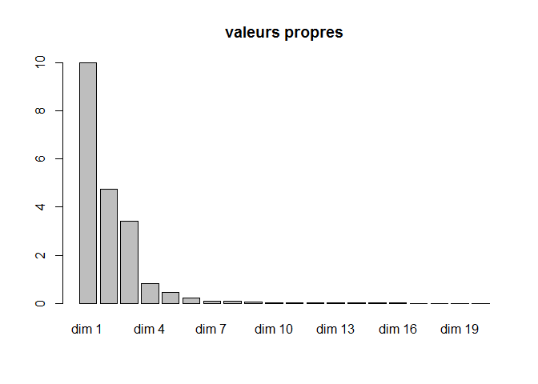

```r
library(ggplot2)
library(grid)
library(factoextra)
library(plotly)
barplot(res.pca$eig[,1],main="valeurs propres",names.arg=paste("dim",1:nrow(res.pca$eig)))
```

## 5.2 Etude de la qualité de l’ACP

### * Les valeurs propres :

Ceci est parce que l’échelle des différentes variables dans l’ensemble de données est très variable ; nous pouvons le voir en traçant la variance des différentes colonnes dans la trame de données ( mise à l’échelle régulière sur la gauche , logarithmique à droite)

[output not shown]

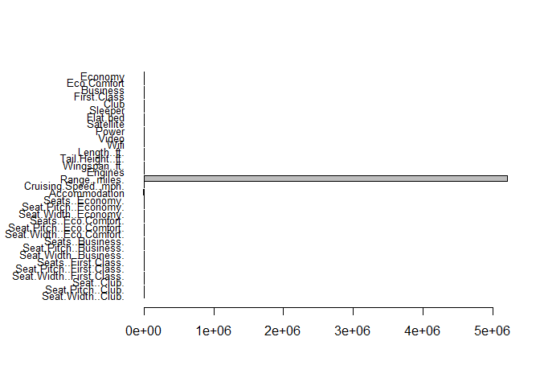

```r
# verify by plotting variance of columns
mar <- par()$mar
par(mar=mar+c(0,5,0,0))
barplot(sapply(data, var), horiz=T, las=1, cex.names=0.8)
```

[output not shown]

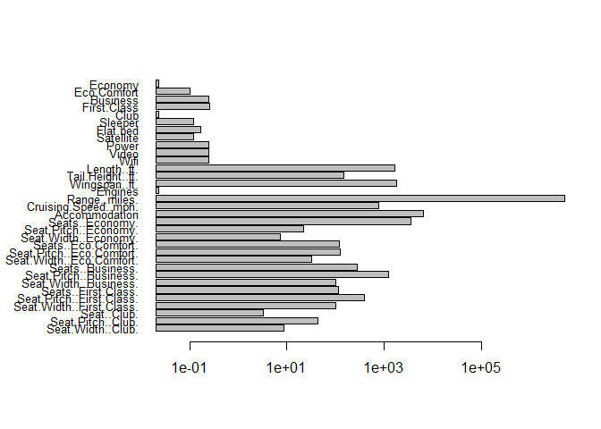

```r
barplot(sapply(data, var), horiz=T, las=1, cex.names=0.8, log='x')
```

```r
par(mar=mar)
```

## 5.3 Interprétations :

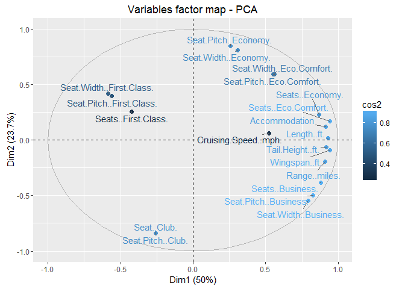

```r
p2=fviz_pca_var(res.pca, geom=c("point","text"),col.var="cos2")
p2
```

D’après le cercle de corrélation on déduit que les variables sont bien représentées. La première composante résume 50.02% de l’inertie totale alors que la deuxième présente 23.68% de la contribution totale.

### * Corrélation entre les variables:

la variable Seat.Width..Business est corrélée négativement avec la variable Seat.Width..first.class et ceci est due aux diferance entre les différant sièges chacune a ses propres caractéristique .

Nous pouvons voir qu’il y a assez de fortes corrélations positives entre les variables quantitatives relatives aux caractéristiques physiques de l’avion, comme chacun d’entre eux sont liés à la taille globale de l’avion . Remarquablement il existe une relation presque parfaitement linéaire entre la hauteur d’envergure et de la queue, qui est peut-être liée à un principe de l’ingénierie aéronautique dont je suis pas au courant. avec : *L’envergure d’une aile c’est la largueure totale de l’avion* Longueur de la corde moyenne c’est la distance entre le bord d’attaque et le bord de fuite ,à un endroit donné de l’aile.

[figure not shown]

En revanche, les variables Seat.Width..Economy et Seats.width.First.Class ne sont pas corrélés entre eux ( ils forment un angle de 90°) car une siégé ne peut pas être à la fois première classe et économique

Ces interprétations peuvent être affinés a l’aide des résultats numériques.

## 5.4 contribution des individus par rapport à la première axe

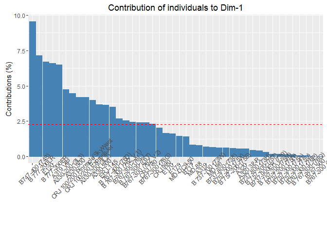

```r
fviz_pca_contrib(res.pca , choice="ind" ,axes=1)
```

## 5.5 contribution des individus par rapport à la deuxième axe

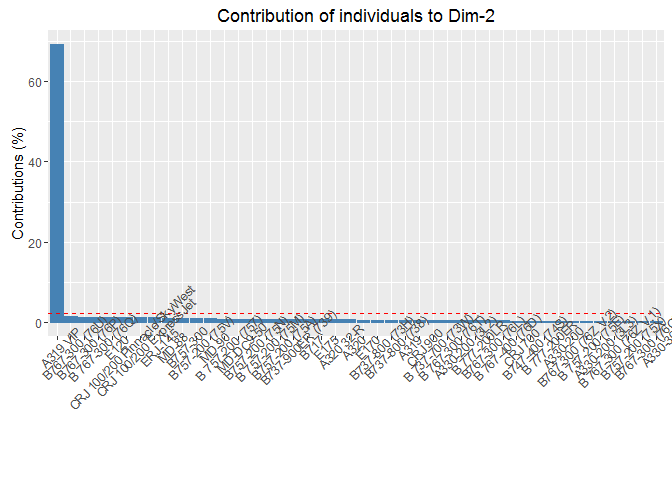

```r
fviz_pca_contrib(res.pca , choice="ind" ,axes=2)
```

## 5.6 Eboulis des valeurs propres/Scree pot

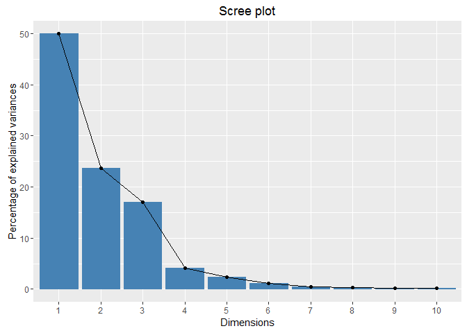

```r
p3=fviz_screeplot(res.pca)
p3
```

## 5.7 représentation des individus

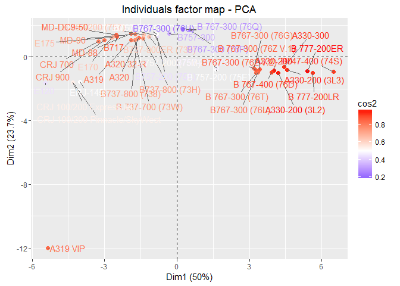

```r
library(factoextra)


p1=fviz_pca_ind(res.pca,geom=c("point","text"),col.ind = "cos2")+scale_color_gradient2(low='blue',mid='white',high='red',midpoint=0.5)
p1
```

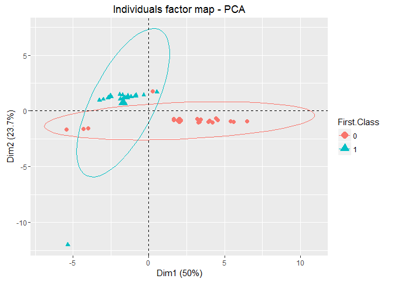

```r
# habillage selon la variable first .classe

p4=fviz_pca_ind(res.pca,habillage=30,label=T,addEllipses=T)
p4
```

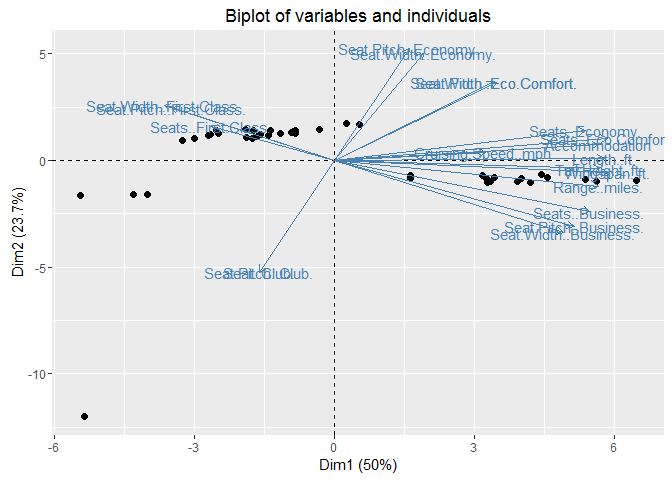

```r
p5=fviz_pca_biplot(res.pca, label="var", select.ind = list(contrib = 44))

p5
```

## 5.8 représentation des Avions selon les Hébergement en première classe

```r
p1<-res.pca$ind$coord[,1]
p1
```

```
##                         A319                     A319 VIP
##                   -1.8891736                   -5.3451263
##                         A320                    A320 32-R
##                   -1.5787989                   -1.5787989
##                     A330-200               A330-200 (3L2)
##                    4.0203641                    4.1991360
##               A330-200 (3L3)                     A330-300
##                    4.5701959                    4.4357398
##                         B717              B 737-700 (73W)
##                   -2.4882712                   -1.7513115
##               B737-800 (738)               B737-800 (73H)
##                   -1.6527294                   -1.3976906
##             B737-900ER (739)               B747-400 (74S)
##                   -1.1561870                    6.4891411
##               B757-200 (75A)              B 757-200 (75E)
##                   -0.8281056                    1.6380439
##              B 757-200 (75M)               B757-200 (75N)
##                   -0.9061811                   -0.8744141
##              B 757-200 (757)               B757-200 (75V)
##                   -1.3715852                   -0.8273175
##               B757-200 (75X)                     B757-300
##                    1.6464674                   -0.3227944
##               B767-300 (76G)               B767-300 (76L)
##                    3.1871185                    3.3537890
##               B767-300 (76P)              B 767-300 (76Q)
##                    0.5387665                    0.5387665
##              B 767-300 (76T)               B767-300 (76U)
##                    3.2902316                    0.2592619
##          B 767-300 (76Z V.1)           B767-300 (76Z V.2)
##                    3.4300999                    3.2658415
##              B 767-400 (76D)                  B 777-200ER
##                    3.9248771                    5.3960086
##                  B 777-200LR CRJ 100/200 Pinnacle/SkyWest
##                    5.6135979                   -4.3052448
##       CRJ 100/200 ExpressJet                      CRJ 700
##                   -4.3052448                   -3.2568941
##                      CRJ 900                         E120
##                   -2.9962026                   -5.4374528
##                         E170                         E175
##                   -2.6990168                   -2.6591332
##                      ERJ-145                        MD-88
##                   -4.0107726                   -1.9084567
##                        MD-90                    MD-DC9-50
##                   -1.7271981                   -2.5233451
```

```r
p2<-res.pca$ind$coord[,2]
p2
```

```
##                         A319                     A319 VIP
##                    1.0627044                  -12.0169670
##                         A320                    A320 32-R
##                    1.2068674                    1.2068674
##                     A330-200               A330-200 (3L2)
##                   -0.8494500                   -1.0109265
##               A330-200 (3L3)                     A330-300
##                   -0.8122495                   -0.6432261
##                         B717              B 737-700 (73W)
##                    1.2645834                    1.0346157
##               B737-800 (738)               B737-800 (73H)
##                    1.1356635                    1.1769820
##             B737-900ER (739)               B747-400 (74S)
##                    1.2713933                   -0.9482149
##               B757-200 (75A)              B 757-200 (75E)
##                    1.2921543                   -0.8203545
##              B 757-200 (75M)               B757-200 (75N)
##                    1.3089839                    1.3461351
##              B 757-200 (757)               B757-200 (75V)
##                    1.3924423                    1.4331078
##               B757-200 (75X)                     B757-300
##                   -0.7023941                    1.4463025
##               B767-300 (76G)               B767-300 (76L)
##                   -0.6923859                   -0.9789194
##               B767-300 (76P)              B 767-300 (76Q)
##                    1.6933807                    1.6933807
##              B 767-300 (76T)               B767-300 (76U)
##                   -1.0116452                    1.7618870
##          B 767-300 (76Z V.1)           B767-300 (76Z V.2)
##                   -0.7836712                   -0.8265045
##              B 767-400 (76D)                  B 777-200ER
##                   -0.9785405                   -0.9035833
##                  B 777-200LR CRJ 100/200 Pinnacle/SkyWest
##                   -1.0008502                   -1.6045397
##       CRJ 100/200 ExpressJet                      CRJ 700
##                   -1.6045397                    0.9579862
##                      CRJ 900                         E120
##                    1.0379938                   -1.6521373
##                         E170                         E175
##                    1.1835284                    1.2309414
##                      ERJ-145                        MD-88
##                   -1.5812392                    1.4626485
##                        MD-90                    MD-DC9-50
##                    1.4297764                    1.3920130
```

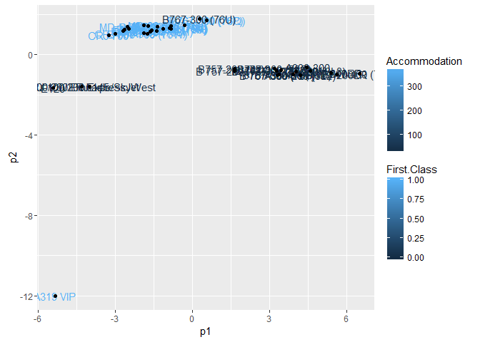

```r
pc<-data.frame(cbind(p1,p2))
ggplot(pc, aes(p1,p2, label=rownames(pc))) + geom_text(data=pc, aes(x = p1, y= p2 , color=First.Class , fill=Accommodation   )) + geom_point()
```

# 6 classification des modèles des Avion selon les sièges

Dans cette partie ,en utilisant l’ACP on va regrouper les Avions selon ces modèles pour mieux visualiser les différentes caractéristique de chaque modèle :

-Airbus -Boeing -CRJ - Embraer E - McDonnell MD

## 6.1 modèle Airbus

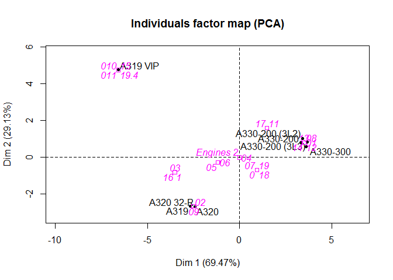

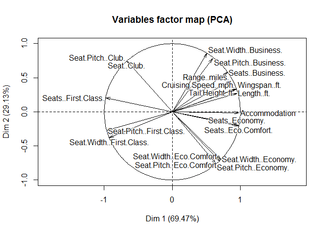

```r
dataA=data[1:8,]
res.pcaA=PCA(dataA,quali.sup=c(1,19,23:33))
```

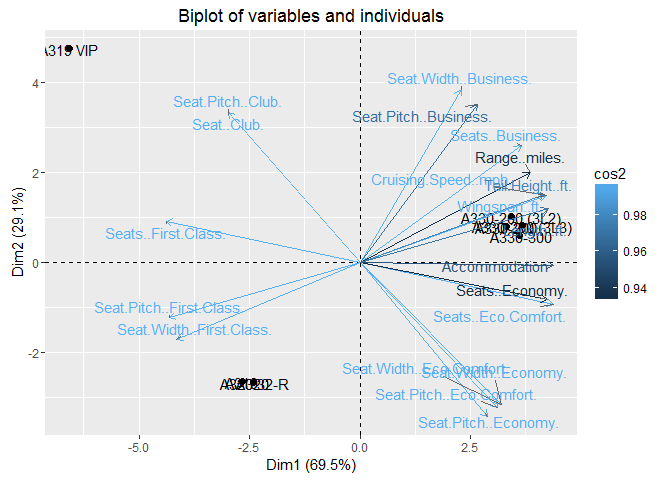

```r
pA=fviz_pca_biplot(res.pcaA,col.var="cos2",select.ind = list(contrib =8))
pA
```

```r
View(dataA)
```

### interprétation :

D’après le cercle de corrélation on déduit que les variables sont bien représentées. La première composante résume 69.5% de l’inertie totale alors que la deuxième présente 29.1% de la contribution totale.

on remarque que les désignations des axes n’ont pas changé puisque on n’a pas changé les variables on a seulement réduit le nombre des individus

on peut voir clairement que les individus Airbus A330-200 (3L2), Airbus A330-200 (3L3),et Airbus 330_300 sont bien corrélées avec la variable seats.Business donc on conclue que ces avion comportent essentiellement les sièges d’affaires.

en revanche on remarque que Airbus A317 VIP est bien corrélé avec les variables seats.first.class et seats.club en effet cet avion ne fait pas partie de la flotte régulière de Delta ,mais l’un des jets d’affaires d’Airbus .ceci est un plan pour les personnes avec de l’argent, pour l’affrètement privé . il comprend “sièges de club” autour des tables pour travailler (ou non) . voici une image de l’intérieur de l’A319 VIP :

[figure not shown]

## 6.2 modèle Boeing et McDonnell

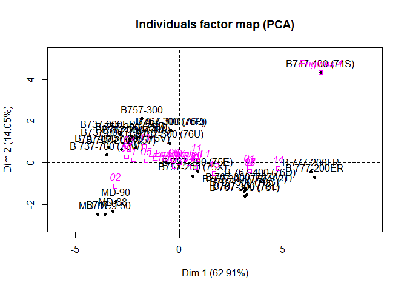

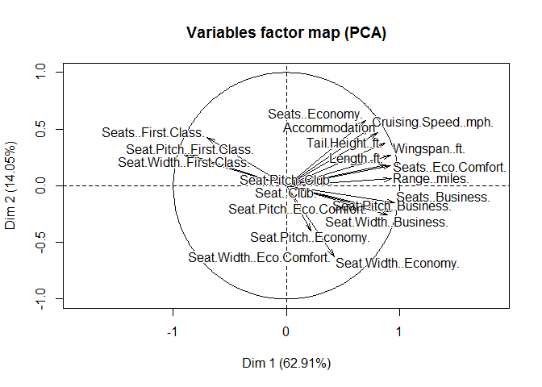

```r
dataB=data[9:33, ]

data1=data[42:44,]
new=rbind(dataB,data1)
View(new)
res.pcan=PCA(new,quali.sup=c(1,19,23:33))
```

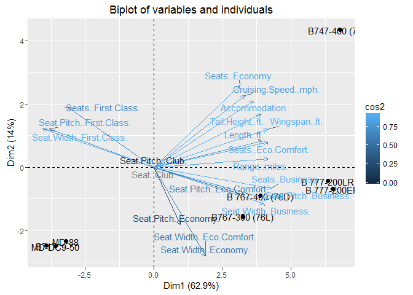

```r
pn=fviz_pca_biplot(res.pcan,col.var="cos2",select.ind = list(contrib =8))
pn
```

### interprétation :

D’après le cercle de corrélation on déduit que les variables sont bien représentées. La première composante résume 62.9% de l’inertie totale alors que la deuxième présente 14% de la contribution totale.

on remarque que Douglas Boeing McDonnel sont les avions avec lesquels la plupart des voyageurs aériens commerciaux sont familiers puisque ils sont corrélés avec les sièges économie et les sièges d’affaires citons les exemples de B777-200ER et B777-20LR

### 6.3 modèle CRJ & Embraer E

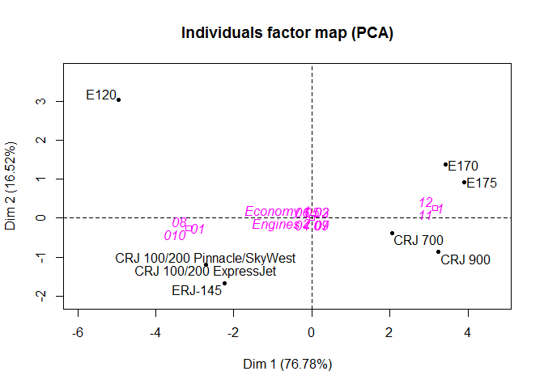

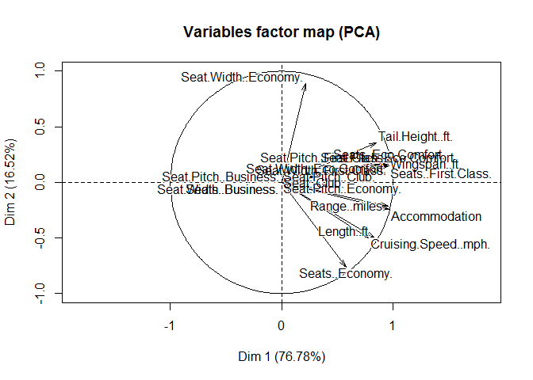

```r
dataC=data[34:41,]
res.pcaC=PCA(dataC,quali.sup=c(1,19,23:33))
```

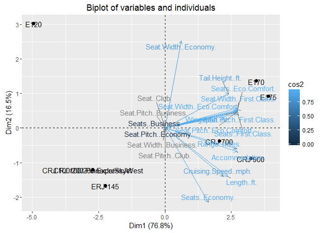

```r
pC=fviz_pca_biplot(res.pcaC,col.var="cos2",select.ind = list(contrib =8))
pC
```

```r
View(dataC)
```

#### interprétation :

D’après le cercle de corrélation on déduit que les variables sont bien représentées. La première composante résume 76.8.9% de l’inertie totale alors que la deuxième présente 16.5% de la contribution totale.

[figure not shown]

# 7 Conclusion

[figure not shown]